# Tarea 7

## Parte 1

Resuelve el ejercicio 7.1.0.1 de las notas (sigue el ejemplo anterior a este ejercicio). Puedes utilizar nnet o el código con el que optimizamos en clase.

Este es el código para generar los datos:

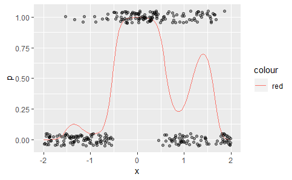

```r
library(tidyverse)
h <- function(x){
    exp(x)/(1 + exp(x))
}
x <- seq(-2,2,0.05)
p <- h(3 + x- 3 * x ^ 2 + 3 * cos(4 * x))
set.seed(280572)
x.2 <- runif(300, -2, 2)
g.2 <- rbinom(300, 1, h(3 + x.2 - 3 * x.2 ^ 2 + 3 * cos(4 * x.2)))
datos <- data.frame(x.2,g.2)
dat.p <- data.frame(x,p)
g <- qplot(x,p, geom='line', col='red')
g + geom_jitter(data = datos, aes(x=x.2,y=g.2), col ='black',
  position =position_jitter(height=0.05), alpha=0.4)
```

Funciones a utilizar:

```r
feed_fow <- function(beta, x){
  a_1 <- h(beta[1] + beta[2] * x) # calcula variable 1 de capa oculta
  a_2 <- h(beta[3] + beta[4] * x) # calcula variable 2 de capa oculta
  a_3 <- beta[5]*cos(beta[6]*x)^2
  a_4 <- beta[7]*sin(beta[8]*x)^2
  p <- h(beta[9] + beta[10] * a_1 + beta[11] * a_2 + beta[12] * a_3 + beta[13] * a_4) #+ beta[16] * a_5 ) # calcula capa de salida
  p
}
devianza_fun <- function(x, y){
    # esta función es una fábrica de funciones
   devianza <- function(beta){
         p <- feed_fow(beta, x)
      - 2 * mean(y*log(p) + (1-y)*log(1-p))
   }
  devianza
}
```

```r
dev <- devianza_fun(x.2, g.2) # crea función dev
## ahora dev toma solamente los 7 parámetros beta:
dev(c(0,0,0,0,0,0,0,0,0,0,0,0,0))
```

```
[1] 1.386294
```

```r
set.seed(5)
salida <- optim(rnorm(15), dev, method = 'BFGS') # inicializar al azar punto inicial
salida
```

```
$`par`
 [1]  2.2474702  2.4693233 -0.2391986  1.4524673  2.7020559
 [6] -0.7090239  2.1710325 -2.0341093 -4.5529516  2.2370385
[11]  1.1367749  2.7972424 -2.1192835 -0.1575344 -1.0717600

$value
[1] 0.6970453

$counts
function gradient
     115      100

$convergence
[1] 1

$message
NULL
```

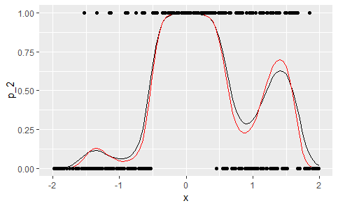

```r
beta <- salida$par
## hacer feed forward con beta encontrados
p_2 <- feed_fow(beta, x)
dat_2 <- data.frame(x, p_2 = p_2)
ggplot(dat_2, aes(x = x, y = p_2)) + geom_line()+
geom_line(data = dat.p, aes(x = x, y = p), col='red') +ylim(c(0,1))+
   geom_point(data = datos, aes(x = x.2, y = g.2))
```

```r
devianza_reg <- function(x, y, lambda){
    # esta función es una fábrica de funciones
   devianza <- function(beta){
         p <- feed_fow(beta, x)
         # en esta regularizacion quitamos sesgos, pero puede hacerse también con sesgos.
        - 2 * mean(y*log(p) + (1-y)*log(1-p)) + lambda*sum(beta[-c(1,3,5)]^2)
   }
  devianza
}
dev_r <- devianza_reg(x.2, g.2, 0.001) # crea función dev
set.seed(5)
salida <- optim(rnorm(16), dev_r, method='BFGS') # inicializar al azar punto inicial
salida
```

```
$`par`
 [1] -0.114022581  1.454056878 -0.396701317  1.399175699
 [5]  5.362558776 -0.875593464  2.145579751 -2.107036184
 [9] -2.727632110  1.469682303  1.458376231  1.383163237
[13] -2.141121542 -0.011174671 -0.076025101 -0.009858956

$value
[1] 0.7330901

$counts
function gradient
     107      100

$convergence
[1] 1

$message
NULL
```

```r
beta <- salida$par
dev(beta)
```

```
[1] 0.700978
```

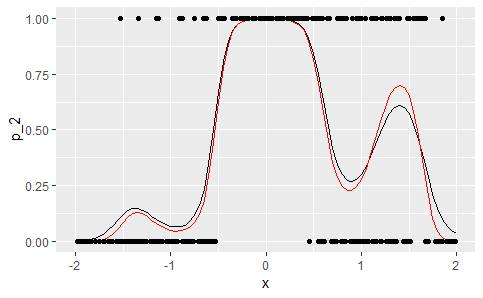

```r
p_2 <- feed_fow(beta, x)
dat_2 <- data.frame(x, p_2 = p_2)
ggplot(dat_2, aes(x = x, y = p_2)) + geom_line()+
geom_line(data = dat.p, aes(x = x, y = p), col='red') +ylim(c(0,1))+
   geom_point(data = datos, aes(x = x.2, y = g.2))
```

- ¿Qué tan bien puedes recuperar la forma verdadera (la función $p$, o la curva roja en la gráfica)?
- ¿Cuántas variables derivadas $a_k$ utilizaste? Intenta usar el mínimo posible.
- A grandes rasgos, ¿puedes capturar todos los movimientos de la función verdadera $p$ con esta muestra de entrenamiento? Explica por qué si puedes o por qué no.

## Parte 2

1. Instala el paquete keras de R en tu computadora. Sigue [estas instrucciones](https://keras.rstudio.com).
2. **Si no funciona el método de arriba en tu computadora** (generalmente por instalaciones de python diferentes, etc), puedes instalar en un contenedor de docker.

Primero instala [docker](https://www.docker.com/get-started) en tu computadora. Baja el archivo Dockerfile del repositorio (se tiene que llamar Dockerfile, sin extensión). En línea de comandos, en el mismo directorio donde está el Dockerfile, corre las siguiente línea:

```
docker build -t aprendizaje-rstudio .
```

Esto va a tomar varios minutos, pero solo hay que correrlo una vez.

Después, cuando quieras usar el contenedor, corre:

```
docker run --rm -p 8787:8787 -e PASSWORD=tupassword -v ~/tu/carpeta/local:/home/rstudio/ aprendizaje-rstudio
```

Nota: en windows la segunda línea debe ser de la forma:

```
docker run --rm -p 8787:8787 -e PASSWORD=tupassword -v /c/Users/miusuario/micarpeta:/home/rstudio/ aprendizaje-rstudio
```

Y abre en Chrome o Safari (o el navegador que uses) la dirección:

http://localhost:8787

Y ahora puedes trabajar en rstudio dentro del contenedor de docker (user: rstudio, password: tupassword).

3. Corre algún ejemplo para checar tu instalación, por ejemplo:

https://keras.rstudio.com/articles/tutorial_basic_regression.html

# Ejemplo:

```r
library(keras)
library(tibble)
boston_housing <- dataset_boston_housing()
c(train_data, train_labels) %<-% boston_housing$train
c(test_data, test_labels) %<-% boston_housing$test
paste0("Training entries: ", length(train_data), ", labels: ", length(train_labels))
```

```
[1] "Training entries: 5252, labels: 404"
```

```r
train_data[1, ] # Display sample features, notice the different scales
```

```
 [1]   1.23247   0.00000   8.14000   0.00000   0.53800   6.14200
 [7]  91.70000   3.97690   4.00000 307.00000  21.00000 396.90000
[13]  18.72000
```

```r
column_names <- c('CRIM', 'ZN', 'INDUS', 'CHAS', 'NOX', 'RM', 'AGE',
                  'DIS', 'RAD', 'TAX', 'PTRATIO', 'B', 'LSTAT')
train_df <- as_tibble(train_data)
colnames(train_df) <- column_names
train_df
```

| CRIM | ZN | INDUS | CHAS | NOX | RM | AGE | DIS | RAD | TAX | PTRATIO | B | LSTAT |
| --- | --- | --- | --- | --- | --- | --- | --- | --- | --- | --- | --- | --- |
| 1.23247 | 0.0 | 8.14 | 0 | 0.5380 | 6.142 | 91.7 | 3.9769 | 4 | 307 | 21.0 | 396.90 | 18.72 |
| 0.02177 | 82.5 | 2.03 | 0 | 0.4150 | 7.610 | 15.7 | 6.2700 | 2 | 348 | 14.7 | 395.38 | 3.11 |
| 4.89822 | 0.0 | 18.10 | 0 | 0.6310 | 4.970 | 100.0 | 1.3325 | 24 | 666 | 20.2 | 375.52 | 3.26 |
| 0.03961 | 0.0 | 5.19 | 0 | 0.5150 | 6.037 | 34.5 | 5.9853 | 5 | 224 | 20.2 | 396.90 | 8.01 |
| 3.69311 | 0.0 | 18.10 | 0 | 0.7130 | 6.376 | 88.4 | 2.5671 | 24 | 666 | 20.2 | 391.43 | 14.65 |
| 0.28392 | 0.0 | 7.38 | 0 | 0.4930 | 5.708 | 74.3 | 4.7211 | 5 | 287 | 19.6 | 391.13 | 11.74 |
| 9.18702 | 0.0 | 18.10 | 0 | 0.7000 | 5.536 | 100.0 | 1.5804 | 24 | 666 | 20.2 | 396.90 | 23.60 |
| 4.09740 | 0.0 | 19.58 | 0 | 0.8710 | 5.468 | 100.0 | 1.4118 | 5 | 403 | 14.7 | 396.90 | 26.42 |
| 2.15505 | 0.0 | 19.58 | 0 | 0.8710 | 5.628 | 100.0 | 1.5166 | 5 | 403 | 14.7 | 169.27 | 16.65 |
| 1.62864 | 0.0 | 21.89 | 0 | 0.6240 | 5.019 | 100.0 | 1.4394 | 4 | 437 | 21.2 | 396.90 | 34.41 |

[output cut: 394 more lines]

```r
train_labels[1:10] # Display first 10 entries
```

```
 [1] 15.2 42.3 50.0 21.1 17.7 18.5 11.3 15.6 15.6 14.4
```

## Normalize features

```r
# Test data is *not* used when calculating the mean and std.
# Normalize training data
train_data <- scale(train_data)
# Use means and standard deviations from training set to normalize test set
col_means_train <- attr(train_data, "scaled:center")
col_stddevs_train <- attr(train_data, "scaled:scale")
test_data <- scale(test_data, center = col_means_train, scale = col_stddevs_train)
train_data[1, ] # First training sample, normalized
```

```
 [1] -0.2719092 -0.4830166 -0.4352220 -0.2565147 -0.1650220
 [6] -0.1762241  0.8120550  0.1165538 -0.6254735 -0.5944330
[11]  1.1470781  0.4475222  0.8241983
```

## Create the model

```r
build_model <- function() {

  model <- keras_model_sequential() %>%
    layer_dense(units = 64, activation = "relu",
                input_shape = dim(train_data)[2]) %>%
    layer_dense(units = 64, activation = "relu") %>%
    layer_dense(units = 1)

  model %>% compile(
    loss = "mse",
    optimizer = optimizer_rmsprop(),
    metrics = list("mean_absolute_error")
  )

  model
}
model <- build_model()
model %>% summary()
```

```
___________________________________________________________________
Layer (type)                  Output Shape              Param #
===================================================================
dense_7 (Dense)               (None, 64)                896
___________________________________________________________________
dense_8 (Dense)               (None, 64)                4160
___________________________________________________________________
dense_9 (Dense)               (None, 1)                 65
===================================================================
Total params: 5,121
Trainable params: 5,121
Non-trainable params: 0
___________________________________________________________________
```

## Train the model

```r
# Display training progress by printing a single dot for each completed epoch.
print_dot_callback <- callback_lambda(
  on_epoch_end = function(epoch, logs) {
    if (epoch %% 80 == 0) cat("\n")
    cat(".")
  }
)
epochs <- 500
# Fit the model and store training stats
history <- model %>% fit(
  train_data,
  train_labels,
  epochs = epochs,
  validation_split = 0.2,
  verbose = 0,
  callbacks = list(print_dot_callback)
)
```

```
................................................................................
................................................................................
................................................................................
................................................................................
................................................................................
................................................................................
....................
```

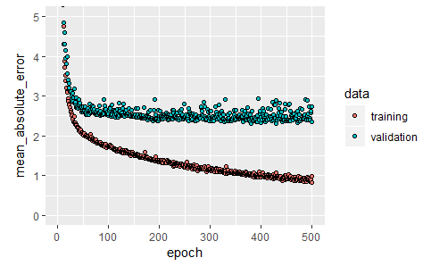

```r
library(ggplot2)
plot(history, metrics = "mean_absolute_error", smooth = FALSE) +
  coord_cartesian(ylim = c(0, 5))
```

```r
# The patience parameter is the amount of epochs to check for improvement.
early_stop <- callback_early_stopping(monitor = "val_loss", patience = 20)
model <- build_model()
history <- model %>% fit(
  train_data,
  train_labels,
  epochs = epochs,
  validation_split = 0.2,
  verbose = 0,
  callbacks = list(early_stop, print_dot_callback)
)
```

```
........................................................................
```

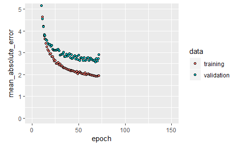

```r
plot(history, metrics = "mean_absolute_error", smooth = FALSE) +
  coord_cartesian(xlim = c(0, 150), ylim = c(0, 5))
```

```r
c(loss, mae) %<-% (model %>% evaluate(test_data, test_labels, verbose = 0))
paste0("Mean absolute error on test set: $", sprintf("%.2f", mae * 1000))
```

```
[1] "Mean absolute error on test set: $3299.20"
```

```r
test_predictions <- model %>% predict(test_data)
test_predictions[ , 1]
```

```
  [1]  8.031562 18.136873 21.610479 31.269722 26.295902 19.734678
  [7] 28.900894 22.953535 19.519722 21.489576 19.299206 17.468840
 [13] 14.978878 43.242676 18.217417 20.491266 28.548819 21.583429
 [19] 18.929979 37.679718 11.008032 13.481588 20.555704 15.002437
 [25] 23.062744 25.192457 31.070232 33.890804 10.082695 22.048376
 [31] 19.026686 13.011682 34.031311 26.653385 17.605917  7.621863
 [37] 15.013299 17.471647 19.093363 28.998896 31.479343 29.157785
 [43] 13.834647 42.357536 30.453350 26.390474 28.380659 16.292202
 [49] 22.774706 23.140295 38.731316 19.987354 11.517086 15.727201
 [55] 36.860985 29.591200 12.119040 49.686172 34.124458 24.863974
 [61] 23.764481 16.423973 12.687450 18.156996 24.100847 24.594179
 [67] 12.452557 24.776800 13.566991  7.651024 37.183453 32.168209
 [73] 25.926043 14.360917 27.728994 19.469818 21.105183 24.875330
 [79] 37.590706  9.894241 20.318380 39.638130 15.223875 13.112091
 [85] 17.111303 20.108313 20.089094 20.375408 23.033506 31.489035
 [91] 21.838198 22.330183 27.086283 45.854218 37.696392 17.734655
 [97] 37.296421 54.001022 27.483723 43.170242 32.626434 19.396173
```